# Medical Insurance Prices - EDA & Econometric Modeling

Marcin Górski

2026-06-16

# Exploratory Data Analysis (EDA)

## Data Overview

```r
medins <- read.csv("medical-charges.csv")

medins$sex    <- as.factor(medins$sex)
medins$smoker <- as.factor(medins$smoker)
medins$region <- as.factor(medins$region)

head(medins, 3)
```

```
##   age    sex   bmi children smoker    region   charges
## 1  19 female 27.90        0    yes southwest 16884.924
## 2  18   male 33.77        1     no southeast  1725.552
## 3  28   male 33.00        3     no southeast  4449.462
```

```r
str(medins)
```

```
## 'data.frame':    1338 obs. of  7 variables:
##  $ age     : int  19 18 28 33 32 31 46 37 37 60 ...
##  $ sex     : Factor w/ 2 levels "female","male": 1 2 2 2 2 1 1 1 2 1 ...
##  $ bmi     : num  27.9 33.8 33 22.7 28.9 ...
##  $ children: int  0 1 3 0 0 0 1 3 2 0 ...
##  $ smoker  : Factor w/ 2 levels "no","yes": 2 1 1 1 1 1 1 1 1 1 ...
##  $ region  : Factor w/ 4 levels "northeast","northwest",..: 4 3 3 2 2 3 3 2 1 2 ...
##  $ charges : num  16885 1726 4449 21984 3867 ...
```

The dataset contains **1338 observations** across **7 variables** describing individual medical insurance charges. Predictors include:

- **Numeric:** age, BMI, number of children
- **Categorical:** sex, smoker status, region

The goal of this analysis is to explore how each of these characteristics relates to insurance charges and to build an econometric model explaining these costs.

## Missing Values

```r
md.pattern(medins, rotate.names = TRUE)
```

```
##  /\     /\
## {  `---'  }
## {  O   O  }
## ==>  V <==  No need for mice. This data set is completely observed.
##  \  \|/  /
##   `-----'
```

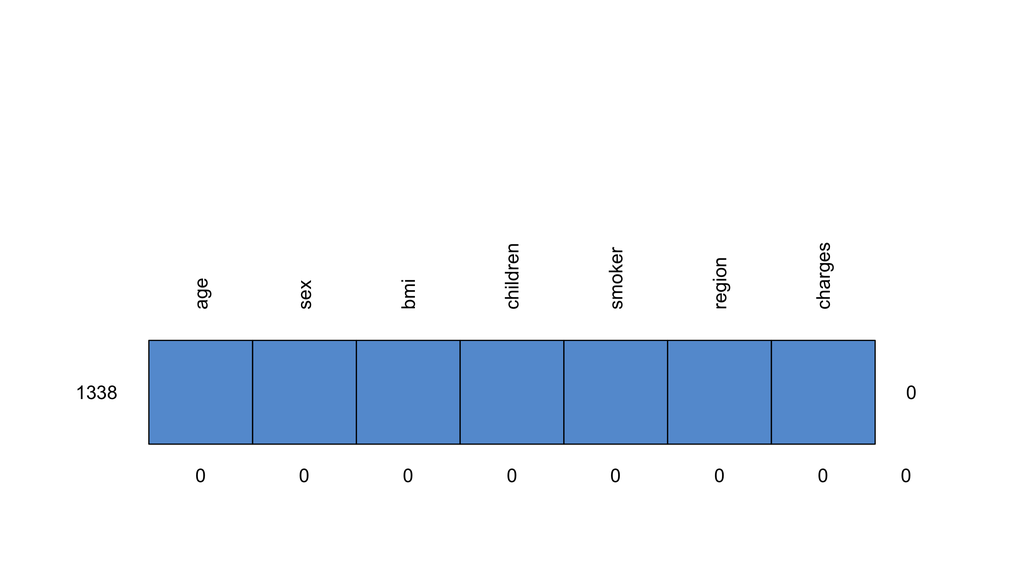

```
##      age sex bmi children smoker region charges
## 1338   1   1   1        1      1      1       1 0
##        0   0   0        0      0      0       0 0
```

No missing values are present in any column - the dataset is complete.

## Variable Distributions

### Categorical Variables

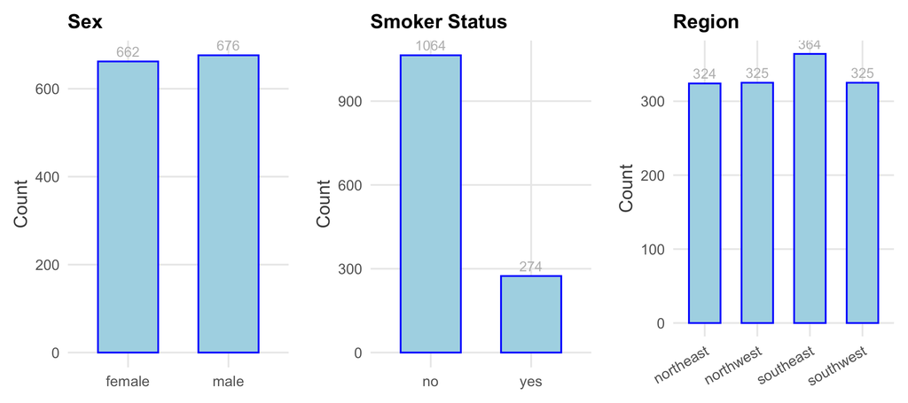

```r
plot_bar_cat <- function(data, var, title) {
  ggplot(data, aes(x = .data[[var]])) +
    geom_bar(fill = "lightblue", color = "blue", width = 0.6) +
    geom_text(stat = "count",
              aes(label = after_stat(count)),
              vjust = -0.5, color = "grey", size = 3.5) +
    labs(title = title, x = NULL, y = "Count") +
    theme_eda
}

grid.arrange(
  plot_bar_cat(medins, "sex",    "Sex"),
  plot_bar_cat(medins, "smoker", "Smoker Status"),
  plot_bar_cat(medins, "region", "Region") +
    theme(axis.text.x = element_text(angle = 30, hjust = 1)),
  nrow = 1
)
```

Sex and region are well balanced. Smokers are a clear minority. Among smokers, males are slightly more represented: **23.52%** of men smoke versus **17.37%** of women. Whether this difference is statistically significant will be tested later.

### Numeric Variables

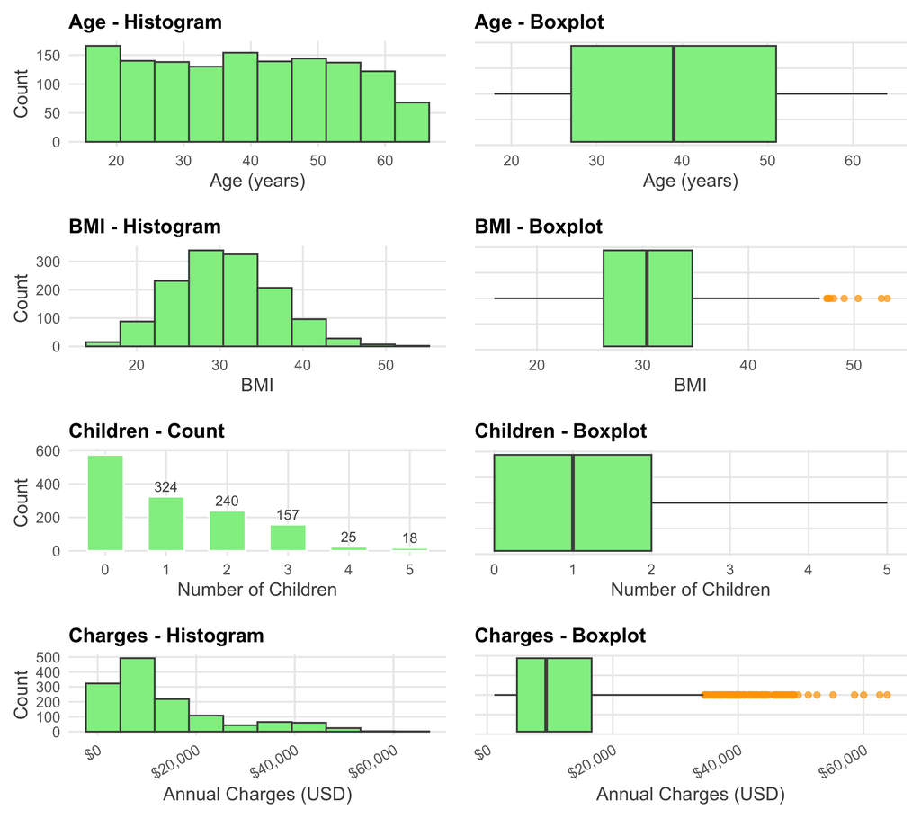

```r
p_age_hist <- ggplot(medins, aes(x = age)) +
  geom_histogram(bins = 10, fill = "lightgreen", color = "grey30") +
  labs(title = "Age - Histogram", x = "Age (years)", y = "Count") +
  theme_eda

p_age_box <- ggplot(medins, aes(x = age)) +
  geom_boxplot(fill = "lightgreen", color = "grey30",
               outlier.color = "orange", outlier.alpha = 0.7) +
  labs(title = "Age - Boxplot", x = "Age (years)") +
  theme_eda +
  theme(axis.text.y = element_blank(), axis.ticks.y = element_blank())

p_bmi_hist <- ggplot(medins, aes(x = bmi)) +
  geom_histogram(bins = 10, fill = "lightgreen", color = "grey30") +
  labs(title = "BMI - Histogram", x = "BMI", y = "Count") +
  theme_eda

p_bmi_box <- ggplot(medins, aes(x = bmi)) +
  geom_boxplot(fill = "lightgreen", color = "grey30",
               outlier.color = "orange", outlier.alpha = 0.7) +
  labs(title = "BMI - Boxplot", x = "BMI") +
  theme_eda +
  theme(axis.text.y = element_blank(), axis.ticks.y = element_blank())

p_chg_hist <- ggplot(medins, aes(x = charges)) +
  geom_histogram(bins = 10, fill = "lightgreen", color = "grey30") +
  scale_x_continuous(labels = scales::dollar_format()) +
  labs(title = "Charges - Histogram", x = "Annual Charges (USD)", y = "Count") +
  theme_eda +
  theme(axis.text.x = element_text(angle = 30, hjust = 1))

p_ch_bar <- ggplot(medins, aes(x = factor(children))) +
  geom_bar(fill = "lightgreen", color = "white", width = 0.6) +
  geom_text(stat = "count", aes(label = after_stat(count)),
            vjust = -0.5, color = "grey30", size = 3.5) +
  labs(title = "Children - Count", x = "Number of Children", y = "Count") +
  theme_eda

p_ch_box <- ggplot(medins, aes(x = children)) +
  geom_boxplot(fill = "lightgreen", color = "grey30",
               outlier.color = "orange", outlier.alpha = 0.7) +
  labs(title = "Children - Boxplot", x = "Number of Children") +
  theme_eda +
  theme(axis.text.y = element_blank(), axis.ticks.y = element_blank())

p_chg_box <- ggplot(medins, aes(x = charges)) +
  geom_boxplot(fill = "lightgreen", color = "grey30",
               outlier.color = "orange", outlier.alpha = 0.7) +
  scale_x_continuous(labels = scales::dollar_format()) +
  labs(title = "Charges - Boxplot", x = "Annual Charges (USD)") +
  theme_eda +
  theme(axis.text.y = element_blank(), axis.ticks.y = element_blank(),
        axis.text.x = element_text(angle = 30, hjust = 1))

grid.arrange(
  p_age_hist, p_age_box,
  p_bmi_hist, p_bmi_box,
  p_ch_bar, p_ch_box,
  p_chg_hist, p_chg_box,
  nrow = 4, ncol = 2
)
```

```r
cat("Age:\n");      quantile(medins$age,      probs = c(0, .01, .25, .5, .75, .95, .99, 1))
```

```
## Age:
```

```
##   0%   1%  25%  50%  75%  95%  99% 100%
##   18   18   27   39   51   62   64   64
```

```r
cat("\nBMI:\n");    quantile(medins$bmi,      probs = c(0, .01, .25, .5, .75, .95, .99, 1))
```

```
##
## BMI:
```

```
##       0%       1%      25%      50%      75%      95%      99%     100%
## 15.96000 17.89515 26.29625 30.40000 34.69375 41.10600 46.40790 53.13000
```

```r
cat("\nChildren:\n");quantile(medins$children, probs = c(0, .01, .25, .5, .75, .95, .99, 1))
```

```
##
## Children:
```

```
##   0%   1%  25%  50%  75%  95%  99% 100%
##    0    0    0    1    2    3    5    5
```

```r
cat("\nCharges:\n"); quantile(medins$charges,  probs = c(0, .01, .25, .5, .75, .95, .99, 1))
```

```
##
## Charges:
```

```
##        0%        1%       25%       50%       75%       95%       99%      100%
##  1121.874  1252.973  4740.287  9382.033 16639.913 41181.828 48537.481 63770.428
```

- **Age** is approximately uniformly distributed.
- **BMI** is roughly normal with a few high-end outliers; fewer than 5% of individuals exceed a BMI of 41.
- **Children** is strongly right-skewed - less than 5% have more than 3 children; the maximum is 5.
- **Charges** are strongly right-skewed with notable outliers. Only 1% pay above $48,500, while the maximum reaches nearly 64,000.

### Correlation Matrix

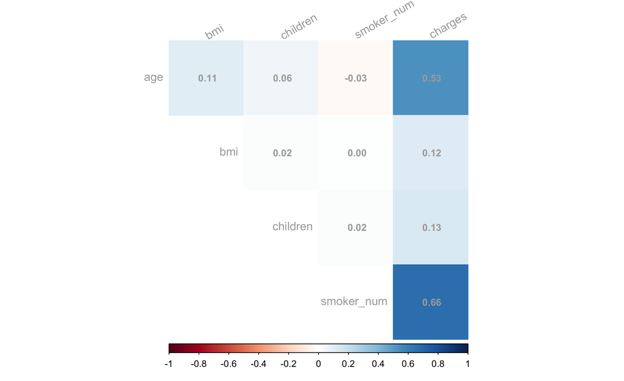

```r
medins$smoker_num <- as.numeric(medins$smoker)

cor_matrix <- cor(
  medins[, c("age", "bmi", "children", "smoker_num", "charges")],
  method = "spearman"
)

corrplot(cor_matrix,
         method      = "color",
         type        = "upper",
         addCoef.col = "darkgrey",
         number.cex  = 0.85,
         tl.col      = "darkgrey",
         tl.srt      = 30,
         diag        = FALSE,
         cl.pos      = "b")
```

## Exploring Relationships

### BMI

To examine the relationship between body mass and other variables, I add a new column `bmi_category`: **Low** (BMI < 18.5), **Normal**, and **High** (BMI > 30, i.e. obese).

```r
medins$bmi_category <- factor(
  ifelse(medins$bmi < 18.5, "Low",
         ifelse(medins$bmi <= 30, "Normal", "High")),
  levels = c("Low", "Normal", "High")
)
```

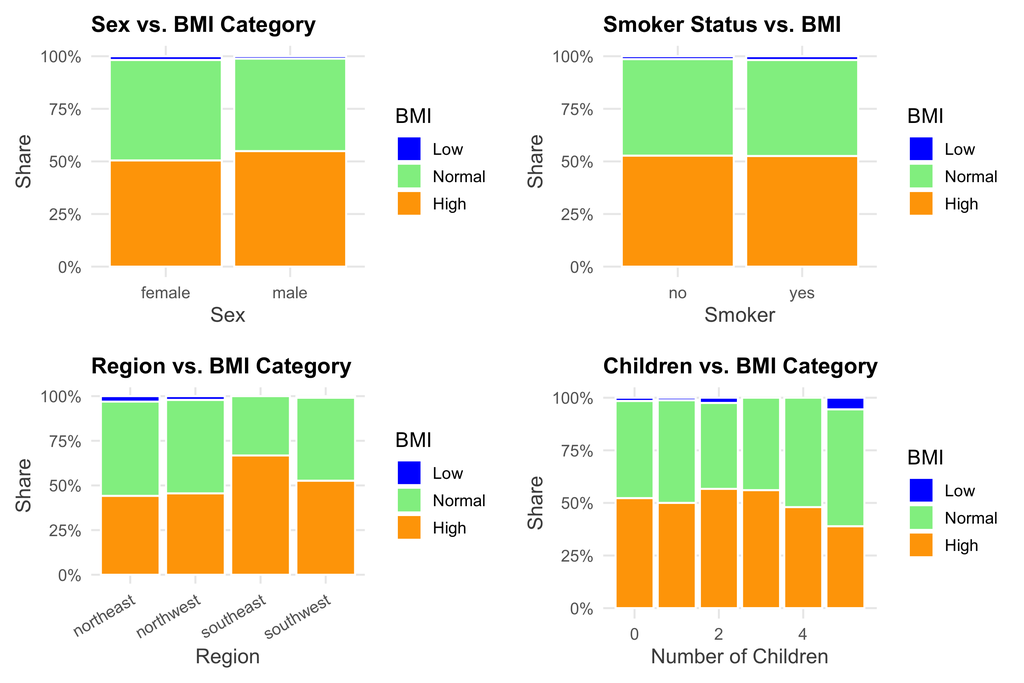

```r
plot_fill_bar <- function(data, x_var, title, x_lab) {
  ggplot(data, aes(x = .data[[x_var]], fill = bmi_category)) +
    geom_bar(color = "white", position = "fill") +
    scale_fill_manual(values = c("Low" = "blue", "Normal" = "lightgreen", "High" = "orange")) +
    scale_y_continuous(labels = scales::percent_format()) +
    labs(title = title, x = x_lab, y = "Share", fill = "BMI") +
    theme_eda
}

grid.arrange(
  plot_fill_bar(medins, "sex",    "Sex vs. BMI Category",      "Sex"),
  plot_fill_bar(medins, "smoker", "Smoker Status vs. BMI",     "Smoker"),
  plot_fill_bar(medins, "region", "Region vs. BMI Category",   "Region") +
    theme(axis.text.x = element_text(angle = 30, hjust = 1)),
  plot_fill_bar(medins, "children", "Children vs. BMI Category", "Number of Children"),
  nrow = 2, ncol = 2
)
```

The only categorical variable that visually appears to relate to BMI is **region**. I’ll verify this with a one-way ANOVA. First, checking assumptions:

```r
for (r in levels(medins$region)) {
  cat("\n--- Lilliefors test for region:", r, "---\n")
  print(
    medins %>% filter(region == r) %>% pull(bmi) %>% lillie.test()
  )
}
```

```
##
## --- Lilliefors test for region: northeast ---
##
##  Lilliefors (Kolmogorov-Smirnov) normality test
##
## data:  .
## D = 0.036625, p-value = 0.3618
##
##
## --- Lilliefors test for region: northwest ---
##
##  Lilliefors (Kolmogorov-Smirnov) normality test
##
## data:  .
## D = 0.026358, p-value = 0.8426
##
##
## --- Lilliefors test for region: southeast ---
##
##  Lilliefors (Kolmogorov-Smirnov) normality test
##
## data:  .
## D = 0.036843, p-value = 0.2679
##
##
## --- Lilliefors test for region: southwest ---
##
##  Lilliefors (Kolmogorov-Smirnov) normality test
##
## data:  .
## D = 0.029848, p-value = 0.6858
```

The Lilliefors test finds no evidence against normality of BMI in any region. Now checking homogeneity of variance:

```r
test_bartlett <- bartlett.test(bmi ~ region, data = medins)
test_bartlett
```

```
##
##  Bartlett test of homogeneity of variances
##
## data:  bmi by region
## Bartlett's K-squared = 18.742, df = 3, p-value = 0.0003091
```

```r
oneway.test(bmi ~ region, data = medins)
```

```
##
##  One-way analysis of means (not assuming equal variances)
##
## data:  bmi and region
## F = 35.834, num df = 3.00, denom df = 739.54, p-value < 2.2e-16
```

The p-value is very small, so I move to post-hoc testing with the **Games-Howell test**:

```r
gamesHowellTest(bmi ~ region, data = na.omit(medins[, c("bmi", "region")]))
```

```
##           northeast northwest southeast
## northwest 0.9999    -         -
## southeast < 2e-16   < 2e-16   -
## southwest 0.0103    0.0059    2.3e-08
```

The results confirm the pattern visible in the chart. Individuals from the **Southeast** have a significantly different BMI from all other regions. The Southeast has the highest proportion of obese individuals, while northern regions have the most people in the normal BMI range.

### Smoker Status vs. Sex

Returning to the earlier question - is the higher smoking rate among men statistically significant? I’ll use a one-sided two-proportion test.

```r
wektor_palacy <- medins %>%
  count(sex, smoker) %>%
  filter(smoker == "yes") %>%
  pull(n)

wektor_plcie <- medins %>%
  count(sex) %>%
  pull(n)

odsetek_palacych <- prop.test(x = wektor_palacy, n = wektor_plcie, alternative = "less")
odsetek_palacych
```

```
##
##  2-sample test for equality of proportions with continuity correction
##
## data:  wektor_palacy out of wektor_plcie
## X-squared = 7.3929, df = 1, p-value = 0.003274
## alternative hypothesis: less
## 95 percent confidence interval:
##  -1.00000000 -0.02384949
## sample estimates:
##    prop 1    prop 2
## 0.1737160 0.2352071
```

The test confirms that **the proportion of smokers is significantly higher among men** (p = 0.0033).

### Smoker Status vs. Age & BMI

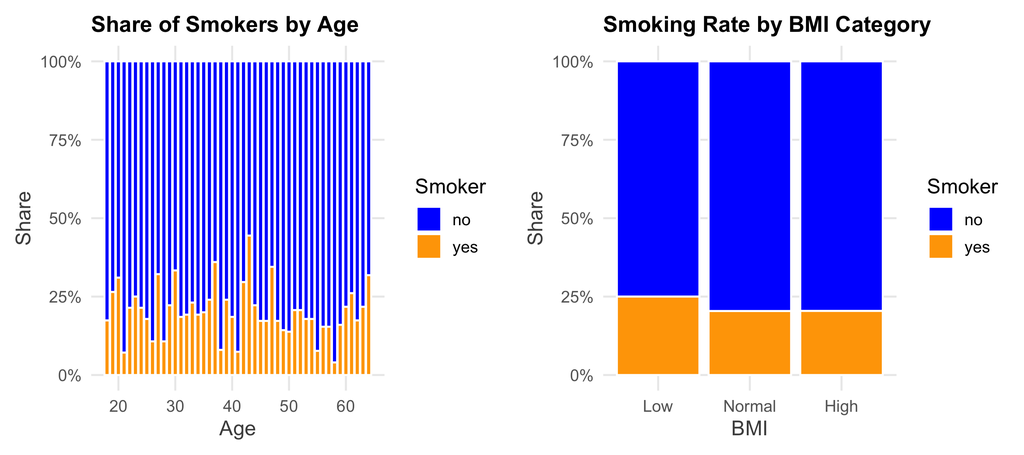

```r
p_smoker_age <- ggplot(medins, aes(x = age, fill = smoker)) +
  geom_bar(color = "white", position = "fill") +
  scale_fill_manual(values = c("yes" = "orange", "no" = "blue")) +
  scale_y_continuous(labels = scales::percent_format()) +
  labs(title = "Share of Smokers by Age", x = "Age", y = "Share", fill = "Smoker") +
  theme_eda

p_smoker_bmi <- ggplot(medins, aes(x = bmi_category, fill = smoker)) +
  geom_bar(color = "white", position = "fill") +
  scale_fill_manual(values = c("yes" = "orange", "no" = "blue")) +
  scale_y_continuous(labels = scales::percent_format()) +
  labs(title = "Smoking Rate by BMI Category", x = "BMI", y = "Share", fill = "Smoker") +
  theme_eda

grid.arrange(p_smoker_age, p_smoker_bmi, nrow = 1)
```

The correlation matrix showed no relationship between smoking and age, and this 100% stacked bar chart confirms it. Regarding BMI, we can formally test if Normal and High BMI groups differ in smoking rates:

```r
palacze_bmi <- medins %>%
  count(bmi_category, smoker) %>%
  filter(bmi_category %in% c("Normal", "High"), smoker == "yes") %>%
  pull(n)

lacznie_bmi <- medins %>%
  count(bmi_category) %>%
  filter(bmi_category %in% c("Normal", "High")) %>%
  pull(n)

odsetek_bmi <- prop.test(x = palacze_bmi, n = lacznie_bmi, alternative = "greater")
odsetek_bmi
```

```
##
##  2-sample test for equality of proportions with continuity correction
##
## data:  palacze_bmi out of lacznie_bmi
## X-squared = 8.7473e-30, df = 1, p-value = 0.5
## alternative hypothesis: greater
## 95 percent confidence interval:
##  -0.03728946  1.00000000
## sample estimates:
##    prop 1    prop 2
## 0.2039152 0.2042553
```

### What Drives Insurance Charges?

#### Age vs. Charges

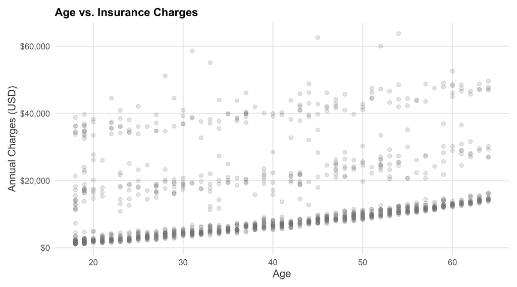

```r
ggplot(medins, aes(x = age, y = charges)) +
  geom_point(size = 2, color = "grey50", alpha = 0.2) +
  scale_y_continuous(labels = scales::dollar_format()) +
  labs(title = "Age vs. Insurance Charges",
       x = "Age", y = "Annual Charges (USD)") +
  theme_eda
```

The scatter plot reveals a near-linear trend at the bottom, but for each age a substantial group pays far higher premiums. These outlying points also form two less distinct upward bands. Smoker status is likely a key factor.

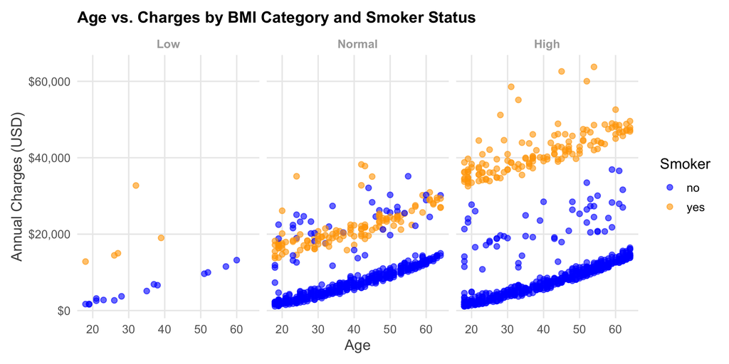

```r
ggplot(medins, aes(x = age, y = charges, color = smoker)) +
  geom_point(size = 2, alpha = 0.6) +
  scale_color_manual(values = c("yes" = "orange", "no" = "blue")) +
  scale_y_continuous(labels = scales::dollar_format()) +
  facet_wrap(~bmi_category, ncol = 3) +
  labs(title = "Age vs. Charges by BMI Category and Smoker Status",
       x = "Age", y = "Annual Charges (USD)", color = "Smoker") +
  theme_eda
```

Those scatter plots shed further light at the structure and reveal three distinct groups: 1. The bottom band is exclusively **non-smokers**. 2. The top band is almost exclusively **obese smokers**. 3. The middle band contains a mix of both, largely **smokers with normal BMI**.

This implies that obesity and smoking interact powerfully in pricing.

#### Other Factors vs. Charges

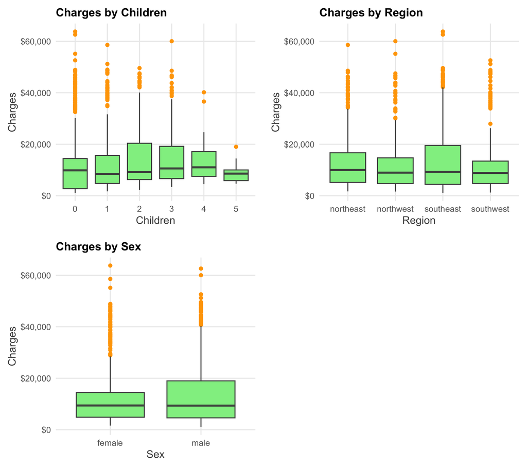

```r
p_ch_chg <- ggplot(medins, aes(x = as.factor(children), y = charges)) +
  geom_boxplot(fill = "lightgreen", color = "grey30", outlier.color = "orange") +
  scale_y_continuous(labels = scales::dollar_format()) +
  labs(title = "Charges by Children", x = "Children", y = "Charges") +
  theme_eda

p_reg_chg <- ggplot(medins, aes(x = region, y = charges)) +
  geom_boxplot(fill = "lightgreen", color = "grey30", outlier.color = "orange") +
  scale_y_continuous(labels = scales::dollar_format()) +
  labs(title = "Charges by Region", x = "Region", y = "Charges") +
  theme_eda

p_sex_chg <- ggplot(medins, aes(x = sex, y = charges)) +
  geom_boxplot(fill = "lightgreen", color = "grey30", outlier.color = "orange") +
  scale_y_continuous(labels = scales::dollar_format()) +
  labs(title = "Charges by Sex", x = "Sex", y = "Charges") +
  theme_eda

grid.arrange(p_ch_chg, p_reg_chg, p_sex_chg, nrow = 2, ncol = 2)
```

The Southeast box reaches the highest, but recall that this region also has the highest obesity rate — so the elevated charges are likely driven by BMI rather than region per se. Medians for sex are nearly identical; differences appear only in the extreme values (consistent with men having a higher smoking rate). A Wilcoxon rank-sum test confirms no baseline difference:

```r
medins %>% filter(sex == "female") %>% pull(charges) %>% lillie.test()
```

```
##
##  Lilliefors (Kolmogorov-Smirnov) normality test
##
## data:  .
## D = 0.1843, p-value < 2.2e-16
```

```r
wilcox.test(charges ~ sex, data = medins)
```

```
##
##  Wilcoxon rank sum test with continuity correction
##
## data:  charges by sex
## W = 221304, p-value = 0.7287
## alternative hypothesis: true location shift is not equal to 0
```

# Regression Analysis

## Base Model

First, let’s build a basic linear model using all available variables.

```r
model_base <- lm(charges ~ age + sex + bmi + children + smoker + region, data=medins)

summary(model_base)$coefficients
```

```
##                    Estimate Std. Error     t value     Pr(>|t|)
## (Intercept)     -11938.5386  987.81918 -12.0857530 5.579044e-32
## age                256.8564   11.89885  21.5866552 7.783217e-89
## sexmale           -131.3144  332.94544  -0.3944020 6.933475e-01
## bmi                339.1935   28.59947  11.8601306 6.498194e-31
## children           475.5005  137.80409   3.4505546 5.769682e-04
## smokeryes        23848.5345  413.15335  57.7232020 0.000000e+00
## regionnorthwest   -352.9639  476.27579  -0.7410914 4.587689e-01
## regionsoutheast  -1035.0220  478.69221  -2.1621870 3.078174e-02
## regionsouthwest   -960.0510  477.93302  -2.0087563 4.476493e-02
```

```r
summary(model_base)$adj.r.squared
```

```
## [1] 0.7494136
```

The `lm()` function automatically encoded categorical variables into dummies (e.g., `sexmale` with female as the base). Right from the start, we get a high Adjusted $R^2$ of 0.7494.

## Interaction Effect

I am introducing a helper variable `obese_smoker` that takes the value 1 for obese smokers, and 0 for everyone else.

> **Critical Note:** Encoding a continuous variable like `bmi` into a binary dummy is often criticized for losing information. A standard textbook approach would suggest a continuous interaction term (`bmi * smoker`) so the penalty scales smoothly with body mass. Interestingly, if you test the continuous interaction on this dataset, it actually yields a *lower* $R^2$ than our `obese_smoker` dummy. This implies that the underlying pricing mechanism isn’t a smooth mathematical slope, but rather a distinct threshold effect (as the graphs suggested). The insurance companies likely apply an additional penalty multiplier only when a smoker crosses the clinical obesity threshold (BMI > 30). Thus, our dummy captures the true business logic better than a continuous interaction.

```r
medins$obese_smoker <- ifelse(medins$smoker=="yes" & medins$bmi_category=="High", 1, 0)

model_interaction <- lm(charges ~ age + sex + bmi + children + smoker + region + obese_smoker, data=medins)

summary(model_interaction)$adj.r.squared
```

```
## [1] 0.8643026
```

Thanks to this single variable, the adjusted R-squared jumped by about 11 percentage points.

## Diagnostics

### Normality of Residuals

```r
lillie.test(model_interaction$residuals)$p.value
```

```
## [1] 0
```

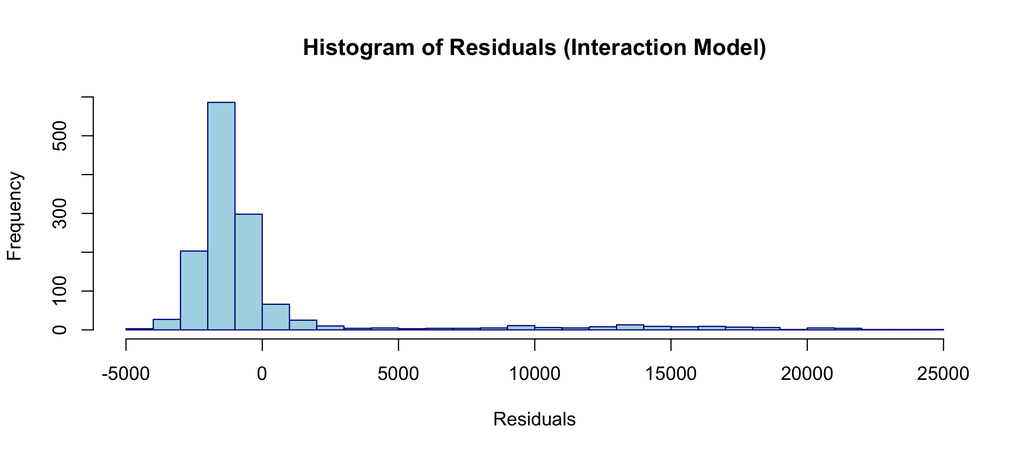

```r
hist(residuals(model_interaction), breaks=30, col = "lightblue", border = "darkblue",
     main = "Histogram of Residuals (Interaction Model)", xlab = "Residuals")
```

Everything points to the fact that the distribution of residuals is far from normal - it has a very long right tail. A common solution is taking the logarithm of the dependent variable.

### Log Transformation of the Dependent Variable

```r
model_log <- lm(log(charges) ~ age + sex + bmi + children + smoker + region + obese_smoker, data=medins)

lillie.test(model_log$residuals)$p.value
```

```
## [1] 1.288814e-215
```

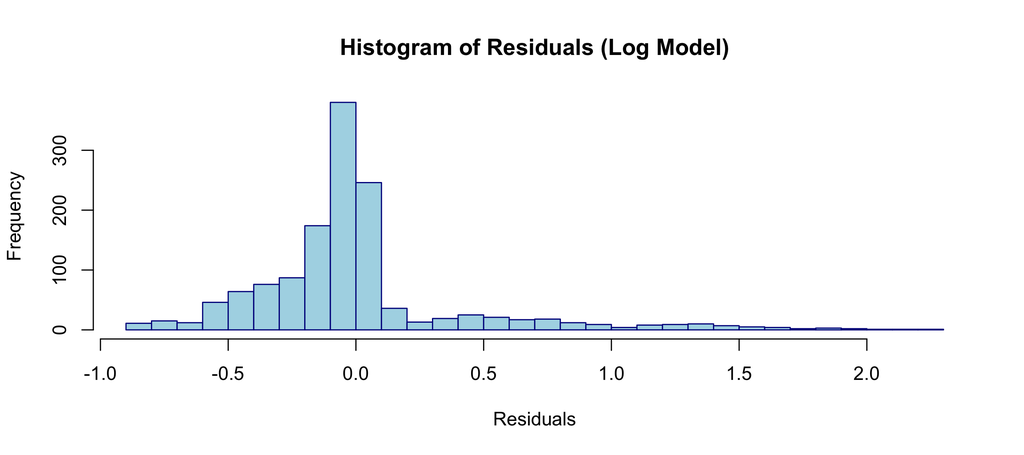

```r
hist(residuals(model_log), breaks = 30, col = "lightblue", border = "darkblue",
     main = "Histogram of Residuals (Log Model)", xlab = "Residuals")
```

### Autocorrelation

Even though the dataset contains cross-sectional data, for the sake of completeness, I will check this assumption.

```r
dwtest(model_interaction)$p.value
```

```
## [1] 0.888536
```

```r
dwtest(model_log)$p.value
```

```
## [1] 0.5668459
```

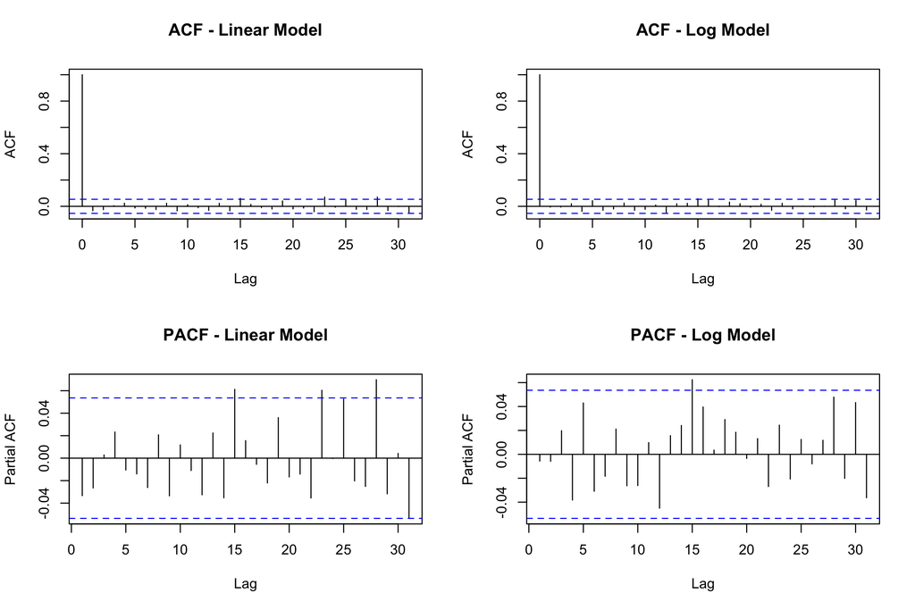

```r
par(mfrow = c(2, 2))

acf(model_interaction$residuals, main = "ACF - Linear Model")
acf(model_log$residuals,         main = "ACF - Log Model")

pacf(model_interaction$residuals, main = "PACF - Linear Model")
pacf(model_log$residuals,         main = "PACF - Log Model")
```

```r
par(mfrow = c(1, 1))
```

The Durbin-Watson test and the ACF plots confirm the lack of autocorrelation in both cases. The values presented on the PACF plots cross the significance interval a few times, but this is not surprising with as many as 30 comparisons (we expect a Type I error in 5 out of 100 cases).

### Heteroscedasticity

```r
bptest(model_interaction)$p.value
```

```
##        BP
## 0.7363952
```

```r
bptest(model_log)$p.value
```

```
##           BP
## 1.637659e-11
```

For the model with the interaction, the Breusch-Pagan test found no grounds to reject the hypothesis of homoscedasticity. It is different for the model with the logarithm - here the p-value is very low, indicating heteroscedasticity.

### Model Comparison - PE Test

The MacKinnon-White-Davidson PE test allows to address the issue of incomparability of R^2s between linear and log-linear models. The idea behind the test is to take the linear model and add an additional explanatory variable: the difference between the predictions from the log model and the logged predictions from the linear model. Analogously, for the log model, it adds the difference between the predictions from the linear model and the exponentially transformed predictions from the log model. It then performs two tests, assuming the correctness of each model.

```r
petest(model_interaction, model_log)
```

```
## PE test
##
## Model 1: charges ~ age + sex + bmi + children + smoker + region + obese_smoker
## Model 2: log(charges) ~ age + sex + bmi + children + smoker + region +
##     obese_smoker
##                           Estimate Std. Error t value Pr(>|t|)
## M1 + log(fit(M1))-fit(M2)  -1202.8     560.07 -2.1476  0.03193 *
## M2 + fit(M1)-exp(fit(M2))      0.0       0.00 17.6929  < 2e-16 ***
## ---
## Signif. codes:  0 '***' 0.001 '**' 0.01 '*' 0.05 '.' 0.1 ' ' 1
```

In both tests, the hypothesis about the correctness of the examined model was rejected, but with much greater certainty for the logarithmic model. Therefore, the only advantage of the log model is that its residuals look slightly closer to normality (which tests don’t even confirm). With this sample size, according to the Central Limit Theorem, non-normal residuals do not invalidate statistical inference. Because of this and the heteroscedasticity exhibited by the log model, I will adopt the **linear model (with interaction)** for further analysis.

### Model Specification Error Test

```r
resettest(model_interaction, 3)$p.value
```

```
## [1] 0.6668561
```

The RESET test found no grounds to reject the hypothesis of correct model specification.

## Dimensionality Reduction

### AIC

To reduce the number of explanatory variables, I will use the **backward stepwise method** based on the **Akaike Information Criterion (AIC)**.

```r
aic_model <- step(model_interaction, direction="backward", trace=0)
formula(aic_model)
```

```
## charges ~ age + sex + bmi + children + smoker + region + obese_smoker
```

The AIC-based method does not reject any variables.

### BIC

Now, I will run the same process based on the stricter **Bayesian Information Criterion (BIC)**.

```r
bic_model <- step(model_interaction, direction="backward", k=log(length(model_interaction$fitted.values)), trace=0)
formula(bic_model)
```

```
## charges ~ age + children + smoker + obese_smoker
```

The result is completely different. The rejected variables are, consecutively: **region, sex, and BMI**. The last one is initially surprising since the EDA showed how important this indicator is. However, the plots showed that obese individuals differ significantly from those with underweight and normal mass - and the impact of obesity is already captured by the interaction variable (`obese_smoker`).

### VIF

The **Variance Inflation Factor (VIF)** will allow us to confirm the hypothesis from the previous sentence by checking multicollinearity among the explanatory variables.

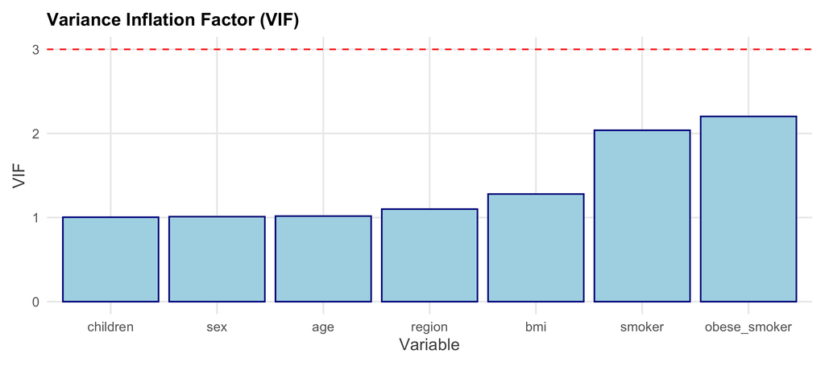

```r
vif_values <- vif(model_interaction)

data.frame(variable = rownames(vif_values), vif = vif_values[,1]) %>%
  ggplot(aes(x = reorder(variable, vif), y = vif)) +
  geom_col(fill = "lightblue", color = "darkblue") +
  geom_hline(yintercept = 3, lty = 2, color = "red") +
  labs(title = "Variance Inflation Factor (VIF)", x = "Variable", y = "VIF") +
  theme_eda
```

Indeed, the index takes the highest value for the `obese_smoker` variable. This is expected, as it is a variable derived directly from `bmi` and `smoker`. While it doesn’t approach a value of 3 (where multicollinearity becomes a problem), it allows us to suspect that the informational value of the `bmi` variable is already contained within `obese_smoker`.

### Adjusted R-Squared Validation

To compare the results suggested by AIC and BIC, I will run the reduction process manually, based on the adjusted $R^2$ value.

There is a problem right away - the `regionnorthwest` dummy is the least significant, but it was created automatically by the `lm()` function. I can estimate the model without the entire `region` variable, but this will result in losing the information carried by `regionsoutheast` and `regionsouthwest`. To verify the validity of this move, I will run an F-test comparing nested models.

```r
anova(lm(charges ~ age + sex + bmi + children + smoker + obese_smoker, data=medins), model_interaction)$"Pr(>F)"[2]
```

```
## [1] 0.005372759
```

The obtained p-value suggests that the `region` variable significantly contributes to improving the model. However, let’s see how the adjusted $R^2$ changes when I sequentially drop the variables suggested by the BIC.

```r
summary(lm(charges ~ age + sex + bmi + children + smoker + obese_smoker, data=medins))$adj.r.squared
```

```
## [1] 0.8633097
```

```r
summary(lm(charges ~ age + bmi + children + smoker + obese_smoker, data=medins))$adj.r.squared
```

```
## [1] 0.8630413
```

```r
summary(lm(charges ~ age + children + smoker + obese_smoker, data=medins))$adj.r.squared
```

```
## [1] 0.8626776
```

I gave up as many as 3 variables (including two statistically significant ones), and the adjusted $R^2$ dropped by barely a tenth of a percentage point. I will save this reduced model as the optimal one.

## Final Model Interpretation

```r
model_final <- lm(charges ~ age + children + smoker + obese_smoker, data=medins)

stat <- glance(model_final)
summary(model_final)$coefficients
```

```
##                Estimate Std. Error   t value      Pr(>|t|)
## (Intercept)  -2614.0591 383.013682 -6.824976  1.331342e-11
## age            266.5901   8.747714 30.475403 3.120272e-155
## children       503.1848 101.905537  4.937758  8.901860e-07
## smokeryes    13324.6547 417.172344 31.940408 1.024378e-166
## obese_smoker 20001.8286 543.036096 36.833332 1.949974e-205
```

```r
cat("Adjusted R-squared:", round(stat$adj.r.squared, 4), "\n")
```

```
## Adjusted R-squared: 0.8627
```

Because there are no logarithms on either side of the equation, I interpret the estimated parameters according to their units (all conclusions assume *ceteris paribus*):

- The **intercept** can be interpreted as a base premium (though negative), and every additional year of life, child, and being a smoker and/or obese acts as an additional charge.
- For each **additional year of life**, the premium increases by an average of **$267**.
- Each **additional child** causes an average premium increase of **$503**.
- **Smokers** pay an average of **$13,325** more in premiums.
- If smoking is combined with obesity (**obese smokers**), the additional “penalty” reaches as high as **$20,000**.